# Laptop_price_prediction_codes

## Introduction:

In our project, we aimed to develop a predictive model for laptop price estimation. By using machine learning techniques, we analyzed laptop features to make accurate price predictions.

We explored different regression-based models, including multi-linear regression, SVR, decision tree, random forest, and XGBoost. Our goal was to understand how factors like processor speed, RAM, storage capacity, brand, and screen size influence laptop prices.

The outcome of our project has practical implications for consumers and industry professionals. By identifying the most accurate model, we can provide insights into the drivers of laptop prices. This helps consumers make informed decisions, aids retailers in pricing strategies, and assists manufacturers in optimizing laptop pricing.

Through our research, we contribute to the field of laptop price prediction and provide guidance to industry stakeholders. Our project showcases the power of machine learning in understanding laptop pricing trends.

Overall, as students, our project allows us to explore data analysis and machine learning while addressing a real-world problem. We are excited to share our findings and contribute to the knowledge of laptop pricing

#### Import libaries

```r
library(tidyverse)
library(dplyr)
library(stringr)
library(corrplot)
library(car)
library(caTools)
library(caret)
library(e1071)
library(rpart)
library(randomForest)
library(MASS)
library(xgboost)
```

#### Import dataset

```r
data = read.csv("laptopData.csv")
```

#### Learning about data insights

```r
head(data)
```

|  | Unnamed..0 | Company | TypeName | Inches | ScreenResolution | Cpu | Ram | Memory | Gpu | OpSys | Weight | Price |
| --- | --- | --- | --- | --- | --- | --- | --- | --- | --- | --- | --- | --- |
| 1 | 0 | Apple | Ultrabook | 13.3 | IPS Panel Retina Display 2560x1600 | Intel Core i5 2.3GHz | 8GB | 128GB SSD | Intel Iris Plus Graphics 640 | macOS | 1.37kg | 71378.68 |
| 2 | 1 | Apple | Ultrabook | 13.3 | 1440x900 | Intel Core i5 1.8GHz | 8GB | 128GB Flash Storage | Intel HD Graphics 6000 | macOS | 1.34kg | 47895.52 |
| 3 | 2 | HP | Notebook | 15.6 | Full HD 1920x1080 | Intel Core i5 7200U 2.5GHz | 8GB | 256GB SSD | Intel HD Graphics 620 | No OS | 1.86kg | 30636.00 |
| 4 | 3 | Apple | Ultrabook | 15.4 | IPS Panel Retina Display 2880x1800 | Intel Core i7 2.7GHz | 16GB | 512GB SSD | AMD Radeon Pro 455 | macOS | 1.83kg | 135195.34 |
| 5 | 4 | Apple | Ultrabook | 13.3 | IPS Panel Retina Display 2560x1600 | Intel Core i5 3.1GHz | 8GB | 256GB SSD | Intel Iris Plus Graphics 650 | macOS | 1.37kg | 96095.81 |
| 6 | 5 | Acer | Notebook | 15.6 | 1366x768 | AMD A9-Series 9420 3GHz | 4GB | 500GB HDD | AMD Radeon R5 | Windows 10 | 2.1kg | 21312.00 |

```r
summary(data)
```

```
   Unnamed..0       Company            TypeName            Inches          ScreenResolution
 Min.   :   0.0   Length:1303        Length:1303        Length:1303        Length:1303
 1st Qu.: 327.0   Class :character   Class :character   Class :character   Class :character
 Median : 652.0   Mode  :character   Mode  :character   Mode  :character   Mode  :character
 Mean   : 652.7
 3rd Qu.: 980.0
 Max.   :1302.0
 NA's   :30
     Cpu                Ram               Memory              Gpu               OpSys
 Length:1303        Length:1303        Length:1303        Length:1303        Length:1303
 Class :character   Class :character   Class :character   Class :character   Class :character
 Mode  :character   Mode  :character   Mode  :character   Mode  :character   Mode  :character




    Weight              Price
 Length:1303        Min.   :  9271
 Class :character   1st Qu.: 31915
 Mode  :character   Median : 52161
                    Mean   : 59956
                    3rd Qu.: 79333
                    Max.   :324955
                    NA's   :30
```

```r
str(data)
```

```
'data.frame':   1303 obs. of  12 variables:
 $ Unnamed..0      : int  0 1 2 3 4 5 6 7 8 9 ...
 $ Company         : chr  "Apple" "Apple" "HP" "Apple" ...
 $ TypeName        : chr  "Ultrabook" "Ultrabook" "Notebook" "Ultrabook" ...
 $ Inches          : chr  "13.3" "13.3" "15.6" "15.4" ...
 $ ScreenResolution: chr  "IPS Panel Retina Display 2560x1600" "1440x900" "Full HD 1920x1080" "IPS Panel Retina Display 2880x1800" ...
 $ Cpu             : chr  "Intel Core i5 2.3GHz" "Intel Core i5 1.8GHz" "Intel Core i5 7200U 2.5GHz" "Intel Core i7 2.7GHz" ...
 $ Ram             : chr  "8GB" "8GB" "8GB" "16GB" ...
 $ Memory          : chr  "128GB SSD" "128GB Flash Storage" "256GB SSD" "512GB SSD" ...
 $ Gpu             : chr  "Intel Iris Plus Graphics 640" "Intel HD Graphics 6000" "Intel HD Graphics 620" "AMD Radeon Pro 455" ...
 $ OpSys           : chr  "macOS" "macOS" "No OS" "macOS" ...
 $ Weight          : chr  "1.37kg" "1.34kg" "1.86kg" "1.83kg" ...
 $ Price           : num  71379 47896 30636 135195 96096 ...
```

#### check for null values

```r
null_values = is.na(data)
table(null_values)
```

```
null_values
FALSE  TRUE
15576    60
```

#### Removing unnamed column

```r
dataset = data[ ,-1]
```

#### Removing null values

```r
null_counts = colSums(is.na(dataset))
print(null_counts)
```

```
         Company         TypeName           Inches ScreenResolution              Cpu              Ram
               0                0                0                0                0                0
          Memory              Gpu            OpSys           Weight            Price
               0                0                0                0               30
```

```r
dataset= drop_na(dataset)
```

#### duplicate values

```r
dataset = distinct(dataset)
```

#### printing the unique values for all the columns

```r
d = sapply(colnames(dataset), function(col) unique(dataset[[col]]))
print(d)
```

```
$Company
 [1] "Apple"     "HP"        "Acer"      "Asus"      "Dell"      "Lenovo"    "Chuwi"     "MSI"
 [9] "Microsoft" "Toshiba"   "Huawei"    "Xiaomi"    "Vero"      "Razer"     "Mediacom"  "Samsung"
[17] "Google"    "Fujitsu"   "LG"

$TypeName
[1] "Ultrabook"          "Notebook"           "Gaming"             "2 in 1 Convertible" "Workstation"
[6] "Netbook"

$Inches
 [1] "13.3" "15.6" "15.4" "14"   "12"   "17.3" "13.5" "12.5" "13"   "18.4" "13.9" "11.6" "25.6" "35.6" "12.3"
[16] "27.3" "24"   "33.5" "?"    "31.6" "17"   "15"   "14.1" "11.3" "10.1"

$ScreenResolution
 [1] "IPS Panel Retina Display 2560x1600"            "1440x900"
```

[output cut: 245 more lines]

#As there is no independent company named Vero but its parent is aspire, we will be renaming any location where Vero is present to Aspire.

```r
dataset$Company = ifelse(dataset$Company == "Vero", "Aspire", dataset$Company)
```

#### “?” is present in inches column, droppping those rows

```r
dataset = dataset %>%
  filter(Inches!='?')
```

#### clean the screen resolution column by extracting only resolution values

```r
dataset$ScreenResolution = sapply(dataset$ScreenResolution, function(x) tail(strsplit(x, " ")[[1]], 1))
```

#### clean the cpu column

```r
dataset = dataset %>%
  mutate(`Cpu Name` = sapply(strsplit(Cpu, " "), function(x) paste(x[1:3], collapse = " ")))

fetch_processor = function(text) {
  if (text == 'Intel Core i7' || text == 'Intel Core i5' || text == 'Intel Core i3') {
    return(text)
  } else {
    if (strsplit(text, " ")[[1]][1] == 'Intel') {
      return('Other Intel Processor')
    } else {
      return('AMD Processor')
    }
  }
}

dataset$`Cpu brand` = sapply(dataset$`Cpu Name`, fetch_processor)
```

#### from cpu column we are going to extract only processing speeds

```r
dataset$ProcessSpeed = sapply(dataset$Cpu, function(x) as.numeric(substr(strsplit(x, " ")[[1]][length(strsplit(x, " ")[[1]])], 1, nchar(strsplit(x, " ")[[1]][length(strsplit(x, " ")[[1]])]) - 3)))
dataset = dataset[-5]
dataset = dataset[-11]
```

#### cleaning ram column, by changing its datatype to int

```r
dataset$Ram = as.integer(substr(dataset$Ram,1, nchar(dataset$Ram)-2))
```

#### cleaning memory column

#we are going to create 2 columns, one as storage type and rom

```r
unique_values = unique(dataset$Memory)


print(unique_values)
```

```
 [1] "128GB SSD"                     "128GB Flash Storage"           "256GB SSD"
 [4] "512GB SSD"                     "500GB HDD"                     "256GB Flash Storage"
 [7] "1TB HDD"                       "128GB SSD +  1TB HDD"          "256GB SSD +  256GB SSD"
[10] "64GB Flash Storage"            "32GB Flash Storage"            "256GB SSD +  1TB HDD"
[13] "256GB SSD +  2TB HDD"          "32GB SSD"                      "2TB HDD"
[16] "64GB SSD"                      "1.0TB Hybrid"                  "512GB SSD +  1TB HDD"
[19] "1TB SSD"                       "256GB SSD +  500GB HDD"        "128GB SSD +  2TB HDD"
[22] "512GB SSD +  512GB SSD"        "16GB SSD"                      "16GB Flash Storage"
[25] "512GB SSD +  256GB SSD"        "512GB SSD +  2TB HDD"          "64GB Flash Storage +  1TB HDD"
[28] "180GB SSD"                     "1TB HDD +  1TB HDD"            "32GB HDD"
[31] "1TB SSD +  1TB HDD"            "?"                             "512GB Flash Storage"
[34] "128GB HDD"                     "240GB SSD"                     "8GB SSD"
[37] "508GB Hybrid"                  "1.0TB HDD"                     "512GB SSD +  1.0TB Hybrid"
[40] "256GB SSD +  1.0TB Hybrid"
```

#Removing the values with ‘?’

```r
dataset = dataset %>%
  filter(Memory !='?')
```

#Replace patterns in Memory column

```r
dataset$Memory = gsub("\\.0", "", dataset$Memory)
dataset$Memory = gsub("GB", "", dataset$Memory)
dataset$Memory = gsub("TB", "000", dataset$Memory)
```

#Split Memory column into two columns

```r
dataset = dataset %>%
  separate(Memory, into = c("first", "second"), sep = "\\+", fill = "right") %>%
  mutate(first = str_trim(first),
         second = str_trim(second))
```

#Create indicator variables for each storage type

```r
dataset = dataset %>%
  mutate(Layer1HDD = if_else(str_detect(first, "HDD"), 1, 0),
         Layer1SSD = if_else(str_detect(first, "SSD"), 1, 0),
         Layer1Hybrid = if_else(str_detect(first, "Hybrid"), 1, 0),
         Layer1Flash_Storage = if_else(str_detect(first, "Flash Storage"), 1, 0),
         first = as.integer(gsub("\\D", "", first)),
         second = as.integer(gsub("\\D", "", second)),
         second = if_else(is.na(second), 0, second),
         Layer2HDD = if_else(str_detect(second, "HDD"), 1, 0),
         Layer2SSD = if_else(str_detect(second, "SSD"), 1, 0),
         Layer2Hybrid = if_else(str_detect(second, "Hybrid"), 1, 0),
         Layer2Flash_Storage = if_else(str_detect(second, "Flash Storage"), 1, 0))
```

#Calculate storage quantities

```r
dataset = dataset %>%
  mutate(HDD = first * Layer1HDD + second * Layer2HDD,
         SSD = first * Layer1SSD + second * Layer2SSD,
         Hybrid = first * Layer1Hybrid + second * Layer2Hybrid,
         Flash_Storage = first * Layer1Flash_Storage + second * Layer2Flash_Storage)
```

#Remove unnecessary columns

```r
dataset = subset(dataset, select = -c(first, second, Layer1HDD, Layer1SSD, Layer1Hybrid, Layer1Flash_Storage, Layer2HDD, Layer2SSD, Layer2Hybrid, Layer2Flash_Storage))
```

#### Cleaning GPU column

```r
table(dataset$Gpu)
```

```
            AMD FirePro W4190M            AMD FirePro W4190M              AMD FirePro W5130M
                             1                              2                              1
            AMD FirePro W6150M                 AMD R17M-M1-70                AMD R4 Graphics
                             1                              1                              1
                AMD Radeon 520                 AMD Radeon 530                 AMD Radeon 540
                            16                             39                              1
            AMD Radeon Pro 455             AMD Radeon Pro 555             AMD Radeon Pro 560
                             1                              1                              1
                 AMD Radeon R2         AMD Radeon R2 Graphics                  AMD Radeon R3
                             5                              4                              1
                 AMD Radeon R4         AMD Radeon R4 Graphics                  AMD Radeon R5
                             3                              5                             11
             AMD Radeon R5 430              AMD Radeon R5 520             AMD Radeon R5 M315
                             1                              1                              1
            AMD Radeon R5 M330             AMD Radeon R5 M420            AMD Radeon R5 M420X
                             5                              7                              3
            AMD Radeon R5 M430                  AMD Radeon R7         AMD Radeon R7 Graphics
                            20                              1                              1
            AMD Radeon R7 M360            AMD Radeon R7 M365X             AMD Radeon R7 M440
                             1                              1                              3
            AMD Radeon R7 M445             AMD Radeon R7 M460             AMD Radeon R7 M465
                            13                              2                              1
            AMD Radeon R9 M385              AMD Radeon RX 540              AMD Radeon RX 550
                             1                              2                              4
             AMD Radeon RX 560              AMD Radeon RX 580              ARM Mali T860 MP4
                             1                              5                              1
            Intel Graphics 620              Intel HD Graphics          Intel HD Graphics 400
                             1                             22                             30
         Intel HD Graphics 405          Intel HD Graphics 500          Intel HD Graphics 505
                             9                             39                             12
         Intel HD Graphics 510          Intel HD Graphics 515          Intel HD Graphics 520
                             4                             13                            177
         Intel HD Graphics 530         Intel HD Graphics 5300          Intel HD Graphics 540
                             1                              2                              1
        Intel HD Graphics 6000          Intel HD Graphics 615          Intel HD Graphics 620
                             5                             14                            269
        Intel HD Graphics 620           Intel HD Graphics 630        Intel Iris Graphics 540
                             1                              4                              2
       Intel Iris Graphics 550   Intel Iris Plus Graphics 640   Intel Iris Plus Graphics 650
                             1                              8                              2
```

[output cut: 19 more lines]

```
                             2                             12                              4
       Nvidia GeForce GTX 970M        Nvidia GeForce GTX 980         Nvidia GeForce GTX 980M
                             5                              1                             10
     Nvidia GeForce GTX1050 Ti         Nvidia GeForce GTX1060         Nvidia GeForce GTX1080
                             1                              1                              1
          Nvidia GeForce MX130           Nvidia GeForce MX150             Nvidia GTX 980 SLI
                             6                             15                              1
           Nvidia Quadro 3000M           Nvidia Quadro M1000M            Nvidia Quadro M1200
                             1                              4                              8
          Nvidia Quadro M2000M            Nvidia Quadro M2200           Nvidia Quadro M2200M
                             2                              2                              3
          Nvidia Quadro M3000M            Nvidia Quadro M500M            Nvidia Quadro M520M
                             1                              1                              2
            Nvidia Quadro M620            Nvidia Quadro M620M
                             5                              1
```

#Create a new ‘Gpu brand’ column

```r
dataset$Gpu_brand <- sapply(strsplit(as.character(dataset$Gpu), " "), function(x) x[1])

table(dataset$Gpu_brand)
```

```
   AMD    ARM  Intel Nvidia
   169      1    684    388
```

```r
dataset = dataset %>%
  filter(Gpu_brand != 'ARM')
```

#drop Gpu column

```r
dataset = dataset[-6]
```

#### cleaning Os coloumn

```r
cat_os = function(inp) {
  if (inp %in% c("Windows 10", "Windows 7", "Windows 10 S")) {
    return("Windows")
  } else if (inp %in% c("macOS", "Mac OS X")) {
    return("Mac")
  } else {
    return("Others/No OS/Linux")
  }
}

dataset$OS_category = sapply(dataset$OpSys, cat_os)

dataset = dataset[-6]
```

#### Cleaning weight column

```r
u = unique(dataset$Weight)
print(u)
```

```
  [1] "1.37kg"   "1.34kg"   "1.86kg"   "1.83kg"   "2.1kg"    "2.04kg"   "1.3kg"    "1.6kg"    "2.2kg"
 [10] "0.92kg"   "1.22kg"   "2.5kg"    "1.62kg"   "1.91kg"   "2.3kg"    "1.35kg"   "1.88kg"   "1.89kg"
 [19] "1.65kg"   "2.71kg"   "1.2kg"    "1.44kg"   "2.8kg"    "2kg"      "2.65kg"   "2.77kg"   "3.2kg"
 [28] "1.49kg"   "2.4kg"    "2.13kg"   "2.43kg"   "1.7kg"    "1.4kg"    "1.8kg"    "1.9kg"    "3kg"
 [37] "1.252kg"  "2.7kg"    "2.02kg"   "1.63kg"   "1.96kg"   "1.21kg"   "2.45kg"   "1.25kg"   "1.5kg"
 [46] "2.62kg"   "1.38kg"   "1.58kg"   "1.85kg"   "1.23kg"   "2.16kg"   "2.36kg"   "7.2kg"    "2.05kg"
 [55] "1.32kg"   "1.75kg"   "0.97kg"   "2.56kg"   "1.48kg"   "1.74kg"   "1.1kg"    "1.56kg"   "2.03kg"
 [64] "1.05kg"   "5.4kg"    "4.4kg"    "1.90kg"   "1.29kg"   "2.0kg"    "1.95kg"   "2.06kg"   "1.12kg"
 [73] "3.49kg"   "3.35kg"   "2.23kg"   "?"        "2.9kg"    "4.42kg"   "2.69kg"   "2.37kg"   "4.7kg"
 [82] "3.6kg"    "2.08kg"   "4.3kg"    "1.68kg"   "1.41kg"   "4.14kg"   "2.18kg"   "2.24kg"   "2.67kg"
 [91] "4.1kg"    "2.14kg"   "1.36kg"   "2.25kg"   "2.15kg"   "2.19kg"   "2.54kg"   "3.42kg"   "5.8kg"
[100] "1.28kg"   "2.33kg"   "1.45kg"   "2.79kg"   "8.23kg"   "1.26kg"   "1.84kg"   "0.0002kg" "2.6kg"
[109] "2.26kg"   "3.25kg"   "1.59kg"   "1.13kg"   "1.42kg"   "1.78kg"   "1.10kg"   "1.15kg"   "1.27kg"
[118] "1.43kg"   "2.31kg"   "1.16kg"   "1.64kg"   "2.17kg"   "1.47kg"   "3.78kg"   "1.79kg"   "0.91kg"
[127] "1.99kg"   "4.33kg"   "1.93kg"   "1.87kg"   "2.63kg"   "3.4kg"    "3.14kg"   "1.94kg"   "1.24kg"
[136] "4.6kg"    "4.5kg"    "8.4kg"    "2.73kg"   "1.39kg"   "2.29kg"   "2.59kg"   "2.94kg"   "11.1kg"
[145] "1.14kg"   "3.8kg"    "6.2kg"    "3.31kg"   "1.09kg"   "3.21kg"   "1.19kg"   "1.98kg"   "1.17kg"
[154] "4.36kg"   "1.71kg"   "2.32kg"   "4.2kg"    "1.55kg"   "0.81kg"   "1.18kg"   "2.72kg"   "1.31kg"
[163] "0.920kg"  "3.74kg"   "1.76kg"   "1.54kg"   "2.83kg"   "2.07kg"   "2.38kg"   "3.58kg"   "1.08kg"
[172] "2.20kg"   "0.98kg"   "2.75kg"   "1.70kg"   "2.99kg"   "1.11kg"   "2.09kg"   "4kg"      "3.0kg"
[181] "0.99kg"   "0.69kg"   "3.52kg"   "2.591kg"  "2.21kg"   "3.3kg"    "2.191kg"  "2.34kg"   "4.0kg"
```

```r
dataset = dataset %>%
  filter(Weight != '?')
```

#### Remove last two characters and convert ‘Weight’ column to float

```r
dataset$Weight <- as.numeric(substr(dataset$Weight, 1, nchar(dataset$Weight) - 2))
```

#### Convert ‘Inches’ column to float

```r
dataset$Inches = as.numeric(dataset$Inches)

summary(dataset)
```

```
   Company            TypeName             Inches      ScreenResolution        Ram             Weight
 Length:1240        Length:1240        Min.   :10.10   Length:1240        Min.   : 1.000   Min.   : 0.0002
 Class :character   Class :character   1st Qu.:14.00   Class :character   1st Qu.: 4.000   1st Qu.: 1.5000
 Mode  :character   Mode  :character   Median :15.60   Mode  :character   Median : 8.000   Median : 2.0400
                                       Mean   :15.14                      Mean   : 8.527   Mean   : 2.0810
                                       3rd Qu.:15.60                      3rd Qu.: 8.000   3rd Qu.: 2.3300
                                       Max.   :35.60                      Max.   :64.000   Max.   :11.1000
     Price         Cpu brand          ProcessSpeed        HDD              SSD             Hybrid
 Min.   :  9271   Length:1240        Min.   :0.900   Min.   :   0.0   Min.   :   0.0   Min.   :   0.000
 1st Qu.: 32592   Class :character   1st Qu.:2.000   1st Qu.:   0.0   1st Qu.:   0.0   1st Qu.:   0.000
 Median : 52694   Mode  :character   Median :2.500   Median :   0.0   Median : 256.0   Median :   0.000
 Mean   : 60557                      Mean   :2.304   Mean   : 244.9   Mean   : 184.9   Mean   :   6.055
 3rd Qu.: 79813                      3rd Qu.:2.700   3rd Qu.: 500.0   3rd Qu.: 256.0   3rd Qu.:   0.000
 Max.   :324955                      Max.   :3.600   Max.   :2000.0   Max.   :1000.0   Max.   :1000.000
 Flash_Storage      Gpu_brand         OS_category
 Min.   :  0.000   Length:1240        Length:1240
 1st Qu.:  0.000   Class :character   Class :character
 Median :  0.000   Mode  :character   Mode  :character
 Mean   :  4.529
 3rd Qu.:  0.000
 Max.   :512.000
```

#—————————————————————————————————-

##Analysis and Visualization

#### 1.which is the most used storage type in the dataset

```r
memory_counts = count(data, Memory)

# Print the value counts
print(memory_counts)
```

| Memory | n |
| --- | --- |
|  | 30 |
| 1.0TB HDD | 1 |
| 1.0TB Hybrid | 9 |
| 128GB Flash Storage | 4 |
| 128GB HDD | 1 |
| 128GB SSD | 74 |
| 128GB SSD + 1TB HDD | 92 |
| 128GB SSD + 2TB HDD | 2 |
| 16GB Flash Storage | 7 |
| 16GB SSD | 3 |

[output cut: 31 more lines]

#Ans: SSD

#### correlation between price and storage type

```r
price_correlation = cor(dataset$Price, dataset[10:13])
```

#### Print the correlation coefficients for ‘Price’

```r
print(price_correlation)
```

```
            HDD       SSD      Hybrid Flash_Storage
[1,] -0.3827848 0.6737999 -0.03040446   -0.03425068
```

#### 4.How does the weight of laptops affect their price?

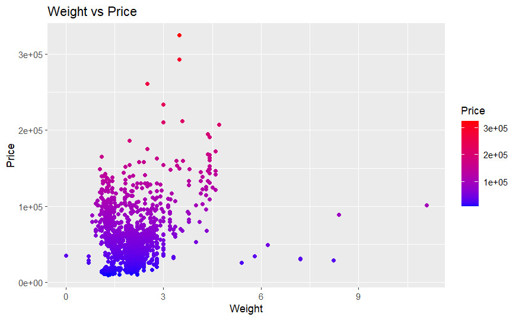

```r
ggplot(data = dataset, aes(x = Weight, y = Price, color = Price)) +
  geom_point() +
  labs(x = "Weight", y = "Price", title = "Weight vs Price") +
  scale_color_gradient(low = "blue", high = "red")
```

#### common operating system

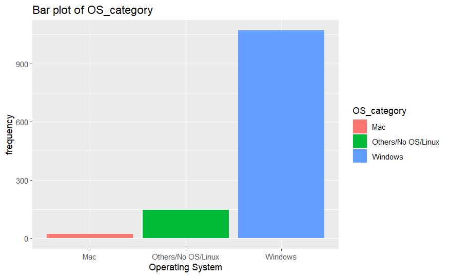

```r
ggplot(data = dataset,aes(x = OS_category, fill= OS_category))+
  geom_bar()+
  xlab('Operating System')+
  ylab('frequency')+
  ggtitle("Bar plot of OS_category")
```

#### 1.How does the type of laptop affect its price?

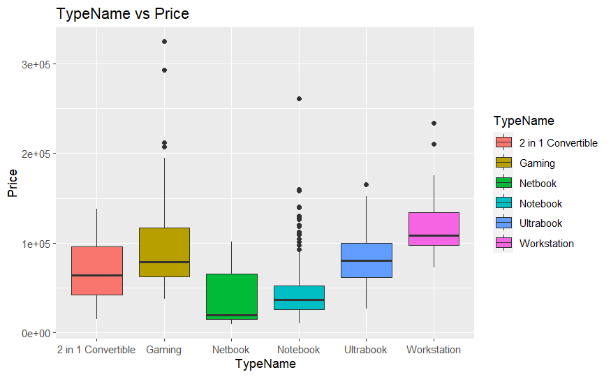

```r
ggplot(data = dataset, aes(x = TypeName, y = Price, fill = TypeName)) +
  geom_boxplot() +
  labs(x = "TypeName", y = "Price", title = "TypeName vs Price")
```

#### 2.How does the ram of laptop affect its price?

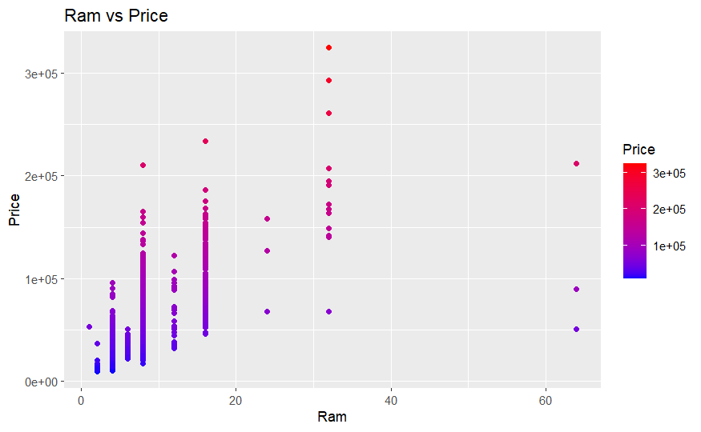

```r
ggplot(data = dataset, aes(x = Ram, y = Price, color = Price)) +
  geom_point() +
  labs(x = "Ram", y = "Price", title = "Ram vs Price") +
  scale_color_gradient(low = "blue", high = "red")
```

#### 3.How does the Gpu brand of laptop affect its price?

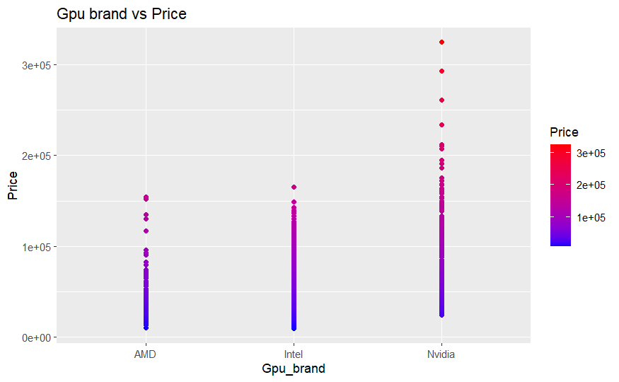

```r
ggplot(data = dataset, aes(x = Gpu_brand, y = Price, color = Price)) +
  geom_point() +
  labs(x = "Gpu_brand", y = "Price", title = "Gpu brand vs Price") +
  scale_color_gradient(low = "blue", high = "red")
```

#### 4.How does the Cpu brand of laptop affect its price?

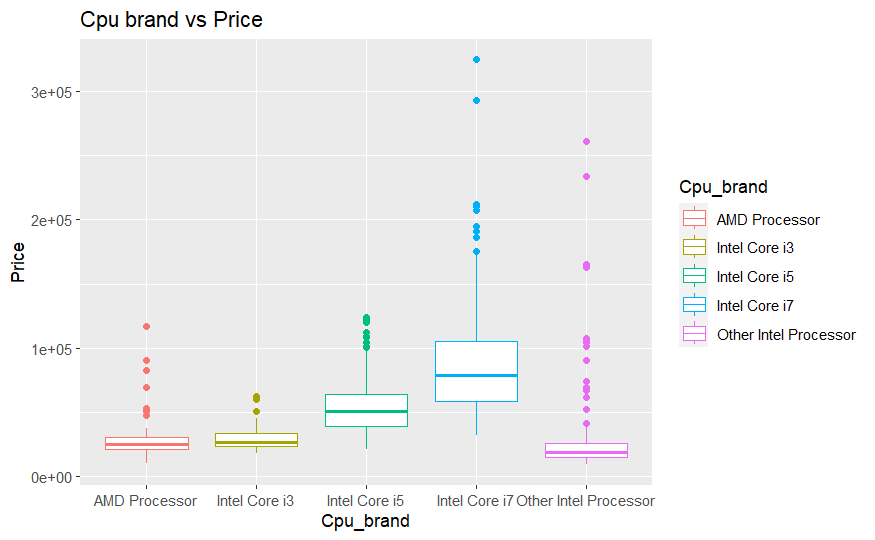

```r
dataset = dataset %>%
  rename_with(~ "Cpu_brand", .cols = "Cpu brand")

ggplot(data = dataset, aes(x = Cpu_brand, y = Price, color = Cpu_brand)) +
  geom_boxplot() +
  labs(x = "Cpu_brand", y = "Price", title = "Cpu brand vs Price")
```

#### 5.Company name Vs Price

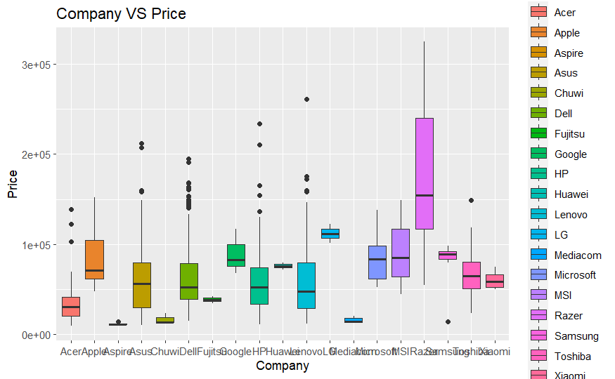

```r
ggplot(data= dataset, aes(x= Company, y= Price, fill= Company))+
  geom_boxplot()+
  ggtitle("Company VS Price")
```

#### 6.How does the processing speed of laptop affect its price?

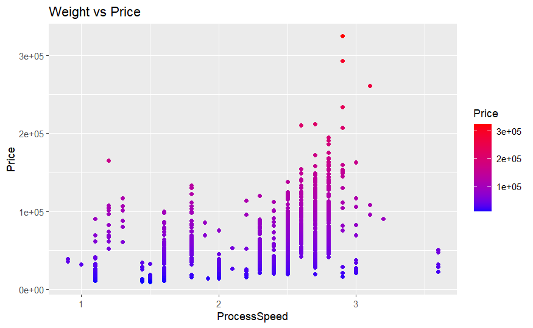

```r
ggplot(data = dataset, aes(x = ProcessSpeed, y = Price, color = Price)) +
   geom_point() +
   labs(x = "ProcessSpeed", y = "Price", title = "Weight vs Price") +
   scale_color_gradient(low = "blue", high = "red")
```

#### 7. How does Operating system effects the price

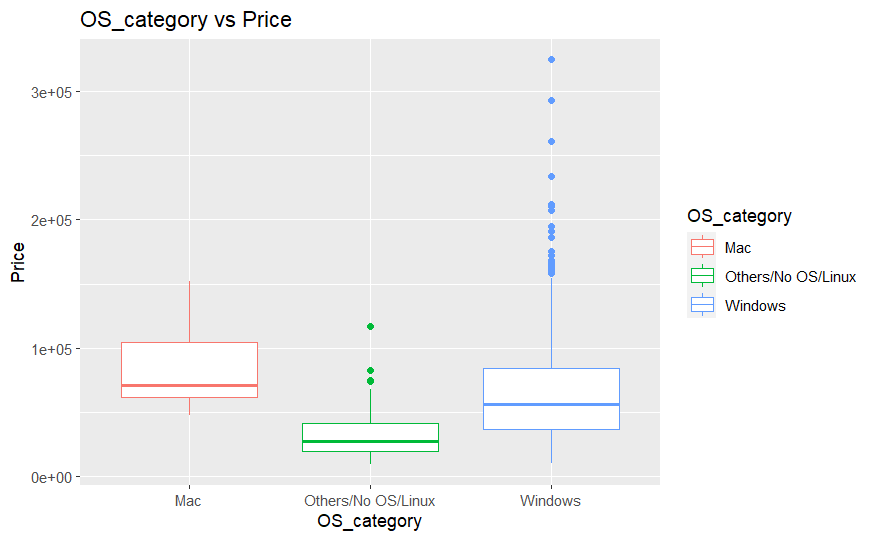

```r
ggplot(data = dataset, aes(x = OS_category, y = Price, color = OS_category)) +
  geom_boxplot() +
  labs(x = "OS_category", y = "Price", title = "OS_category vs Price")
```

#### 8.How does the type of laptop affect its price?

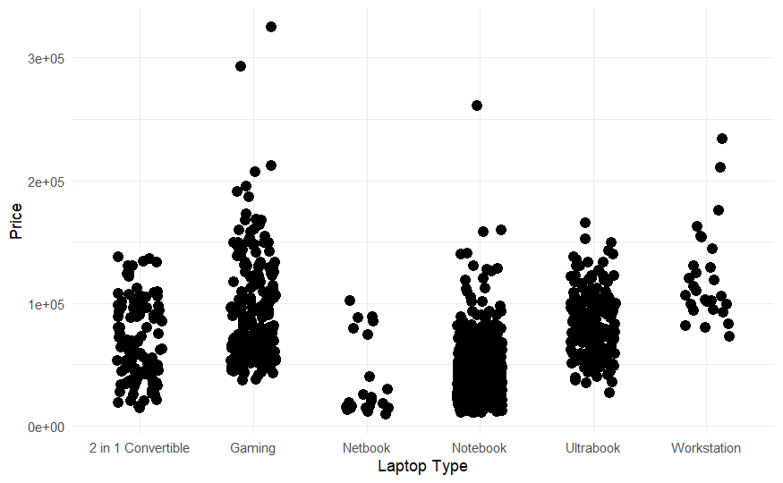

```r
ggplot(data = dataset, aes(x = TypeName, y = Price, fill = TypeName)) +
  geom_point(position = position_jitter(width = 0.2), size = 3) +
  theme_minimal() +
  labs(x = "Laptop Type", y = "Price") +
  guides(fill = FALSE) +
  theme(legend.position = "none")
```

### Price density

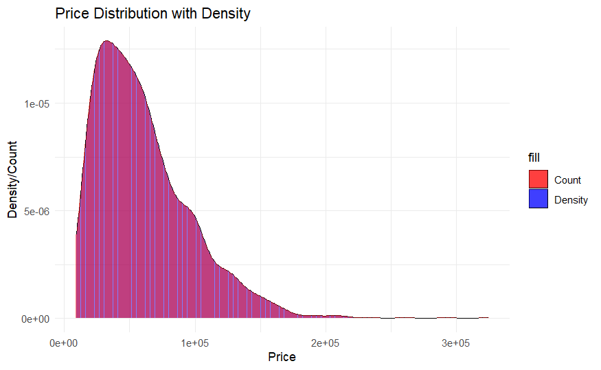

```r
ggplot(dataset, aes(x = Price)) +
  geom_density(aes(fill = "Density"), alpha = 0.5) +
  geom_bar(aes(y = ..density.., fill = "Count"), alpha = 0.5, stat = "density") +
  scale_fill_manual(values = c("Density" = "blue", "Count" = "red")) +
  labs(title = "Price Distribution with Density", x = "Price", y = "Density/Count") +
  theme_minimal()
```

As price density is skewed and I’m trying to fit a regression model, I would like to to make a log transformation to make it normal.

#### plot using log transformation

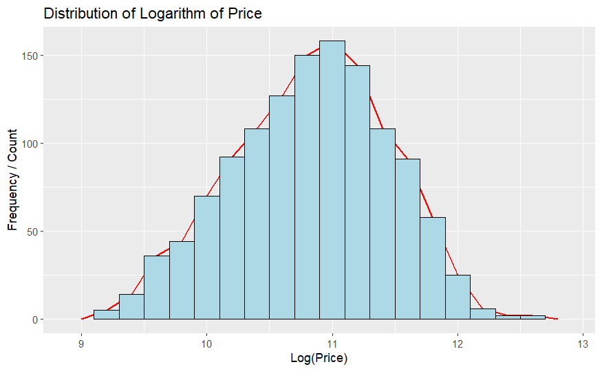

```r
ggplot(dataset, aes(x = log(Price))) +
  geom_freqpoly(binwidth = 0.2, size = .8, color = "red") +
  geom_histogram(binwidth = 0.2, fill = "lightblue", color = "black") +
  xlab("Log(Price)") +
  ylab("Frequency / Count") +
  ggtitle("Distribution of Logarithm of Price")
```

#### Using log transformation in price column

```r
dataset$Price = log(dataset$Price)
```

#### Encoding the catagorical variable

```r
# Specify the categorical columns
catcols <- c("ScreenResolution", "Company", "TypeName", "OS_category", "Cpu_brand", "Gpu_brand")

# Encode categorical variables as integers using label encoding
for (col in catcols) {
  dataset[[col]] <- as.integer(factor(dataset[[col]]))
}
```

#### heatmap of the correlation matrix

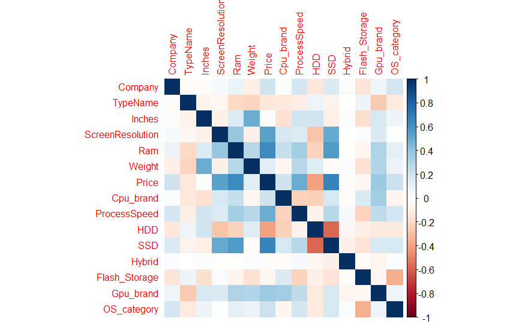

```r
# Compute the correlation matrix
cor_matrix <- cor(dataset)

# Create a heatmap of the correlation matrix
corrplot(cor_matrix, method = "color", type = "full", tl.cex = 0.8)
```

### Checking for multicollinearity

#### Compute the variance inflation factors (VIF)

```r
vif_values <- vif(lm(Price ~ ., data = dataset))

# Print the VIF values
print(vif_values)
```

```
         Company         TypeName           Inches ScreenResolution              Ram           Weight
        1.108696         1.136068         1.403210         1.433680         1.982606         1.633193
       Cpu_brand     ProcessSpeed              HDD              SSD           Hybrid    Flash_Storage
        1.494438         1.507107         1.712329         2.747172         1.039857         1.301244
       Gpu_brand      OS_category
        1.461526         1.215567
```

#——————————————————————————————-

## Building Models

#### Removing outliers using robust regression

```r
library(MASS)
model <- rlm(Price ~ ., data = dataset)
residuals <- residuals(model)


mad <- median(abs(residuals - median(residuals)))
threshold <- 3 * mad
outliers <- which(abs(residuals) > threshold)


data_no_outliers <- dataset %>%
  filter(!row_number() %in% outliers)
```

#### Creating training set and test set

```r
set.seed(123)
split = sample.split(data_no_outliers$Price, SplitRatio = .85)

training_set = subset(data_no_outliers, split== TRUE)
test_set = subset(data_no_outliers, split == FALSE)
y_test = test_set$Price
```

#### 1. Linear regression

```r
reg_1 = lm(formula = Price~.-Hybrid -Weight -TypeName,
           data = training_set)

summary(reg_1)
```

```
Call:
lm(formula = Price ~ . - Hybrid - Weight - TypeName, data = training_set)

Residuals:
     Min       1Q   Median       3Q      Max
-0.70954 -0.19807 -0.00062  0.20702  0.69805

Coefficients:
                   Estimate Std. Error t value Pr(>|t|)
(Intercept)       8.703e+00  1.238e-01  70.289  < 2e-16 ***
Company           8.431e-03  2.249e-03   3.750 0.000188 ***
Inches           -1.166e-02  5.003e-03  -2.331 0.019980 *
ScreenResolution  4.091e-02  3.570e-03  11.460  < 2e-16 ***
Ram               3.800e-02  2.656e-03  14.307  < 2e-16 ***
Cpu_brand         6.710e-02  1.148e-02   5.846 6.84e-09 ***
ProcessSpeed      3.389e-01  2.239e-02  15.137  < 2e-16 ***
HDD              -1.391e-04  2.668e-05  -5.213 2.26e-07 ***
SSD               6.612e-04  8.282e-05   7.983 3.97e-15 ***
Flash_Storage     1.901e-03  3.921e-04   4.847 1.45e-06 ***
Gpu_brand         5.873e-02  1.601e-02   3.668 0.000258 ***
OS_category       1.820e-01  2.544e-02   7.153 1.66e-12 ***
---
Signif. codes:  0 ‘***’ 0.001 ‘**’ 0.01 ‘*’ 0.05 ‘.’ 0.1 ‘ ’ 1

Residual standard error: 0.2823 on 979 degrees of freedom
Multiple R-squared:  0.7645,    Adjusted R-squared:  0.7618
F-statistic: 288.9 on 11 and 979 DF,  p-value: < 2.2e-16
```

```r
#printing adjusted R-squared

summary(reg_1)$adj.r.squared
```

```
[1] 0.7618109
```

```r
y_pred = predict(reg_1, newdata= test_set)
```

#### 2.SVR

```r
reg_2 = svm(formula= Price~.,
            data= training_set,
            type= 'eps-regression',
            kernel= 'radial',
            sigma= 0.1,
            C = 1)
#Prediction

y_pred = predict(reg_2, newdata= test_set)

# Calculate R-squared score
r2_score = R2(y_test, y_pred)

# Calculate mean absolute error
mae = MAE(y_test, y_pred)

# Print R-squared score and mean absolute error
print(paste("R2 score:", r2_score))
```

```
[1] "R2 score: 0.887999619892711"
```

```r
print(paste("MAE:", mae))
```

```
[1] "MAE: 0.162655355829982"
```

#### 3.Decision Tree

```r
reg_3 = rpart(formula = Price~.,
              data = training_set,
               control = rpart.control(minsplit = 50, cp=0.01),
              )

#Prediction

y_pred = predict(reg_3, newdata= test_set)

# Calculate R-squared score
r2_score = R2(y_test, y_pred)

# Calculate mean absolute error
mae = MAE(y_test, y_pred)

# Print R-squared score and mean absolute error
print(paste("R2 score:", r2_score))
```

```
[1] "R2 score: 0.801885579007813"
```

```r
print(paste("MAE:", mae))
```

```
[1] "MAE: 0.21374722793359"
```

#### 4.Random Forest

```r
set.seed(1234)
reg_4 = randomForest(
  x= training_set[-7],
  y= training_set$Price,
  ntree= 200,
  mtry = 4,

)

#prediction

y_pred = predict(reg_4, newdata = test_set)

#calculate R2 score

r2_score = R2(y_pred, y_test)

#calculate MAE score

mae = MAE(y_pred, y_test)

#print R2 and mae score

print(paste("R2 score:", r2_score))
```

```
[1] "R2 score: 0.921137585064212"
```

```r
print(paste("MAE Score:", mae))
```

```
[1] "MAE Score: 0.141683922297544"
```

#### 6.XGBoost

```r
reg_6 = xgboost(data = as.matrix(training_set[-7]), label = training_set$Price, nrounds = 100)
y_pred = predict(reg_5, newdata =as.matrix(test_set[-7]))


#calculate R2 score

r2_score = R2(y_pred, y_test)

#calculate MAE score

mae = MAE(y_pred, y_test)

#print R2 and mae score

print(paste("R2 score:", r2_score))
```

```
[1] "R2 score: 0.973752152182892"
```

```r
print(paste("MAE Score:", mae))
```

```
[1] "MAE Score: 0.0618120692649466"
```

#### Comparison between True value and predicted value using XGBoost

```r
comparison = data.frame(predicted= exp(y_pred), True= exp(y_test))
print(comparison)
```

| predicted | True |
| --- | --- |
| 118995.51 | 135195.34 |
| 90664.90 | 96095.81 |
| 47836.59 | 61735.54 |
| 21763.89 | 20986.99 |
| 45063.55 | 39693.60 |
| 52444.25 | 53226.72 |
| 13650.07 | 13746.24 |
| 25415.10 | 22305.14 |
| 53822.71 | 53173.44 |
| 20329.00 | 19553.76 |

[output cut: 165 more lines]

## CONCLUSION

our project focused on predicting laptop prices using various machine learning models such as multi-linear regression, Support Vector Regression (SVR), decision tree, random forest, and XGBoost. After extensive analysis and evaluation, we found that the XGBoost model outperformed the other models in terms of accuracy and predictive power.

The XGBoost model demonstrated superior performance by effectively capturing the complex relationships between the laptop features and their corresponding prices. Its ability to handle non-linear relationships and feature interactions allowed it to make more accurate predictions compared to the other models.

While multi-linear regression, SVR, decision tree, and random forest models also provided reasonable results, the XGBoost model consistently exhibited higher accuracy and better overall performance. Its ensemble-based approach and optimization techniques enabled it to effectively handle both numerical and categorical features, providing more robust predictions.

It’s worth noting that the choice of the most suitable model may depend on factors such as the size of the dataset, the specific characteristics of the laptop features, and the desired trade-off between interpretability and accuracy. However, in our project, the XGBoost model emerged as the most accurate and reliable choice.

The findings of our project highlight the significance of utilizing advanced machine learning algorithms, such as XGBoost, for predicting laptop prices. These models can offer valuable insights to consumers, retailers, and manufacturers, aiding in decision-making processes related to pricing, marketing, and product development.

Overall, our project demonstrates that the XGBoost model is a powerful tool for accurately predicting laptop prices, providing a foundation for further research and application in the domain of laptop pricing analysis.